# Análisis Estadístico con R

Instalación

Víctor Morales-Oñate

[Sitio Personal](https://sites.google.com/site/moralesonatevictor/), [LinkedIn](https://www.linkedin.com/in/vmoralesonate/), [ResearchGate](https://www.researchgate.net/profile/Victor_Morales-Onate)

9 de abril de 2020

# ¿Cómo instalar R Studio?

Para instalar R-Studio en tu sistema operativo, necesitas seguir los siguientes tres pasos:

1. Instalar R.
2. Instalar R-Studio.
3. Instalar paquetes de R (si se necesita)

## 1. Instalar R

Sigue los siguientes pasos en función del sistema operativo que estés usando.

### Para Windows:

1. Descarga el archivo de configuración binaria para R del siguiente link ([R para Windows](https://cran.r-project.org/)).
2. Abre el archivo *downloaded.exe* e instala R como cualquier programa, la configuración por defecto será sufuciente.

### Para Mac:

1. Descarga la versión apropiada del archivo *.pkg* del siguiente link ([R para Mac](https://cran.r-project.org/)).
2. Abre el archivo *downloaded.pkg* e instala R.

### Para Linux:

1. Para una completa instalación del sistema R en Linux, sigue las instrucciones del siguiente link ([Link](https://cran.r-project.org/bin/linux/ubuntu/README)).
2. Abre el archivo *downloaded.pkg* e instala R.

## 2. Instalar R Studio

En el siguiente link [Download R Studio](https://www.rstudio.com/products/rstudio/download/), la opción *RStudio Desktop Open Source License*, elige el instalador apropiado para tu sistema operativo, descárgalo y luego córrelo para instalar R-Studio.

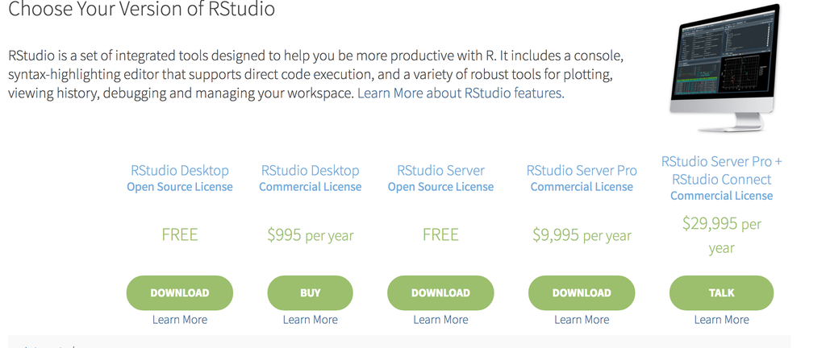

Despliegue de descarga de RStudio

## 3. Instalar paquetes (Opcional)

Si tu necesidad de usar R requiere un paquete/librería en particular para usarla en R-Studio. Puedes seguir las siguientes instrucciones para hacerlo.

1. Corre R Studio
2. Has click en la pestaña *Packages* en la sección inferior derecha y luego click en *install*. Aparecerá la siguiente ventana de diálogo:

[figure not shown]

Así, se termina la instalación de R-Studio.